# Statistical analyses

```r
# Load packages
library(ggplot2)
library(dplyr)
library(lme4)
library(lmerTest)
options(na.action = na.omit)
```

## Load data

```r
load("/home/amira.azizan/Documents/Y320/GenDivDatabase/GDfelids/Data/Popgenden.rda")
```

```r
load("Data/Popgenden.rda")
```

- ref.gen format: FirstAuthor_FirstPublicationTitle_YearofPublication
- ref.den format: FirstAuthor_JournalName_YearofPublication
- average: AVE - only averaged GD available in the study, LOCUS - GD per locus is available and averaging the GD was done by Amira

### 1. log10 transformed variables

1. log10 transformed variables

```r
gen_clus$n.allele_log <- log10(gen_clus$n.allele)
gen_clus$sample.size_log <- log10(gen_clus$sample.size)
gen_clus$DP_log <- log10(gen_clus$DP_mean)
gen_clus$BS_log <- log10(gen_clus$BS)

gen_count$n.allele_log <- log10(gen_count$n.allele)
gen_count$sample.size_log <- log10(gen_count$sample.size)
gen_count$DP_log <- log10(gen_count$DP)
gen_count$BS_log <- log10(gen_count$BS)
```

### 2. Plot the distribution of each variable

2. Plot the distribution of each variable

#### a) Cluster data set

##### DP

##### Ho

[figure not shown]

[figure not shown]

##### He

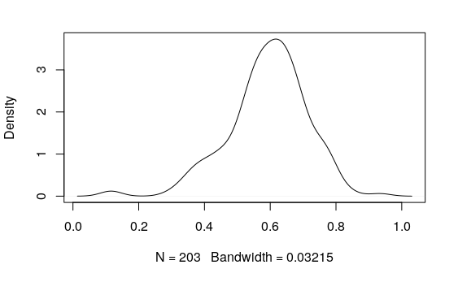

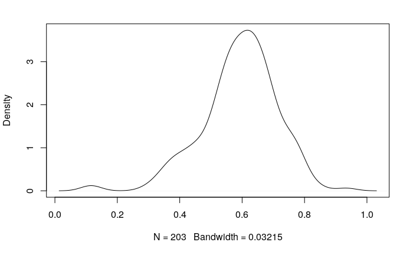

##### Allelic richness

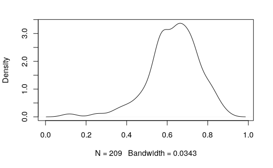

NA

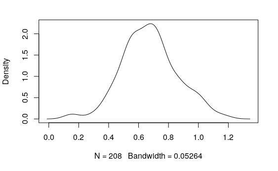

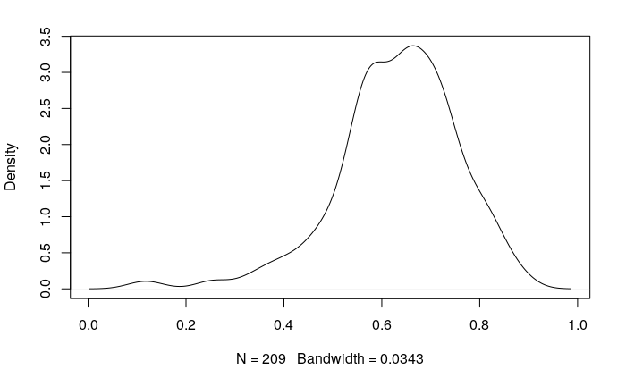

NA

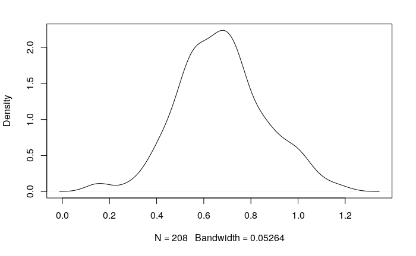

#### b) Country data set

##### DP

##### Ho

[figure not shown]

[figure not shown]

##### He

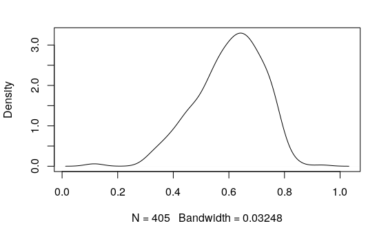

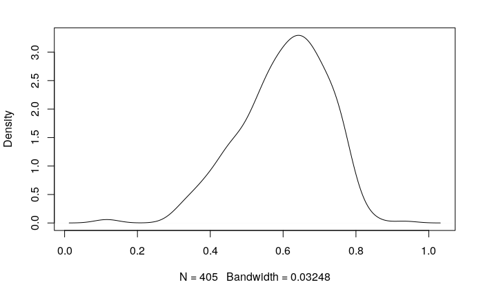

##### Allelic richness

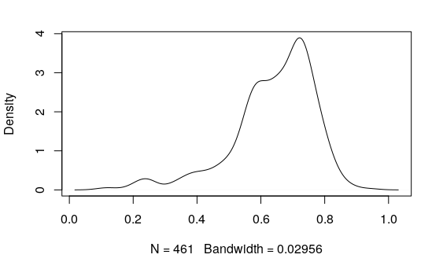

NA

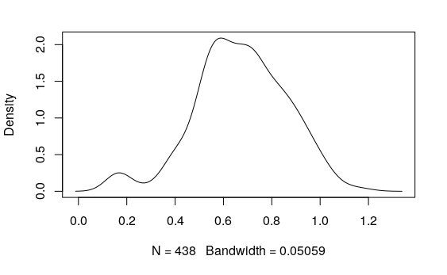

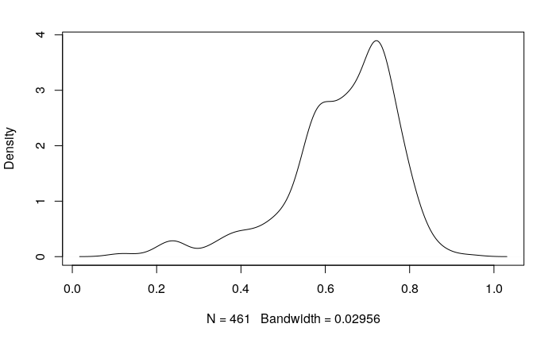

NA

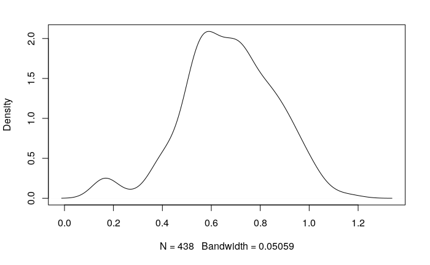

### 3. Simple correlation test with sample size

sample size refers to the mean number of individuals sampled for the GD estimates

3. Simple correlation test with sample size (mean number of individuals sampled for the GD estimates)

- $H_o$ No correlation between GD and sample size size
- $H_1$ GD increases with sample size

[figure not shown]

```r
ggplot(data=gen_clus) + geom_point(aes(x=sp, y=sample.size))
```

```r
# Pearson correlation coefficient
c1 <- cor.test(gen_clus$ho, log10(gen_clus$sample.size), method = "pearson", alt="g")[c("p.value","estimate")]
c2 <- cor.test(gen_clus$he, log10(gen_clus$sample.size), method = "pearson", alt="g")[c("p.value","estimate")]
c3 <- cor.test(gen_clus$n.allele, log10(gen_clus$sample.size), method = "pearson", alt="g")[c("p.value","estimate")]
```